# Assignment 1: PHC 6194 - Spring 21

### Q7. Create a linear regression model using USArrests with Murder as the outcome, and Assault, UrbanPopG (treat it as a categorical variable), and Rape as the predictors, save the model as “Q7”, and print out a summary of the model (10pts)

```r
lin_Q07 = lm(Murder ~ Assault + factor(UrbanPopG) + Rape, data = df_Q03) # Create multiple linear regression model
summary(lin_Q07) # Print summary of model
```

```
##
## Call:
## lm(formula = Murder ~ Assault + factor(UrbanPopG) + Rape, data = df_Q03)
##
## Residuals:
##     Min      1Q  Median      3Q     Max
## -4.2410 -1.8095 -0.3185  1.4235  5.9251
##
## Coefficients:
##                     Estimate Std. Error t value Pr(>|t|)
## (Intercept)        -0.259953   1.033615  -0.251   0.8026
## Assault             0.041795   0.005736   7.286 4.36e-09 ***
## factor(UrbanPopG)2  1.162479   0.980967   1.185   0.2424
## factor(UrbanPopG)3 -1.672348   1.057228  -1.582   0.1209
## factor(UrbanPopG)4 -1.793831   1.062974  -1.688   0.0986 .
## Rape                0.067968   0.054024   1.258   0.2150
## ---
## Signif. codes:  0 '***' 0.001 '**' 0.01 '*' 0.05 '.' 0.1 ' ' 1
##
## Residual standard error: 2.464 on 44 degrees of freedom
## Multiple R-squared:  0.7126, Adjusted R-squared:   0.68
## F-statistic: 21.82 on 5 and 44 DF,  p-value: 6.341e-11
```

### Q8. Use the package “ggplot2” and the data “USArrests” to create separated scatterplots between Murder and Assault by UrbanPopG (with different colors of the points by UrbanPopG, and size of the points proportional to the value of Rape). Add some transparency (alpha=0.9), and save the plot as Q8 (10pts)

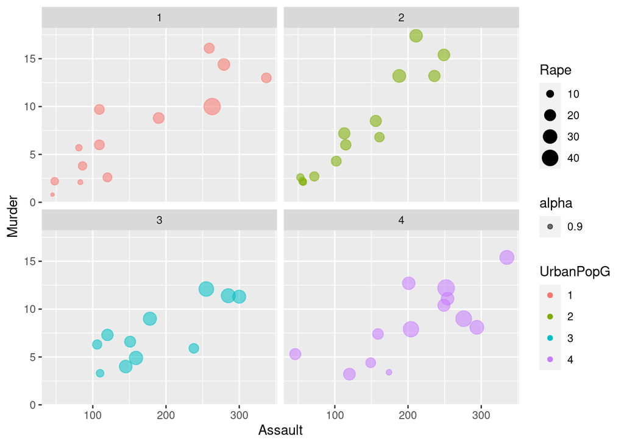

```r
df_Q08 = df_Q02 # Rename dataframe
df_Q08$UrbanPopG = factor(df_Q08$UrbanPopG, labels = c(1, 2, 3, 4)) # Convert column in data frame to factor and define labels
ggplot(data = df_Q08, aes(x = Assault, y = Murder)) + geom_point(aes(color = UrbanPopG, size = Rape, alpha = 0.9)) + facet_wrap(~UrbanPopG) # Create multi-panel plot based on column with formatting/style options
```

### Q9. Based on the plot created in Q8, add the title, labels, and a trend line, remove the background shading, and use a cutom color palette of “Reds” (10pts)

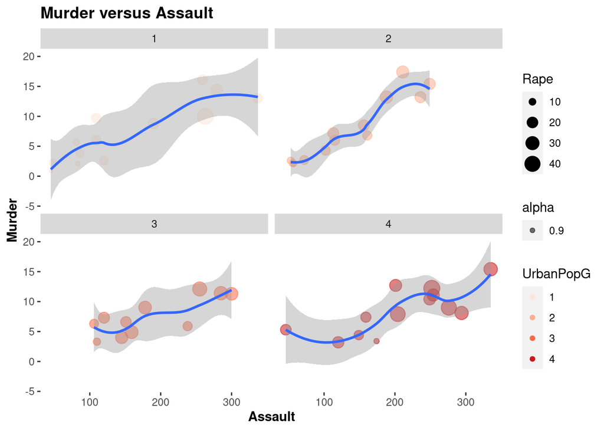

```r
ggplot(data = df_Q08, aes(x = Assault, y = Murder)) + geom_point(aes(color = UrbanPopG, size = Rape, alpha = 0.9)) + scale_color_brewer(palette = "Reds") + stat_smooth() + facet_wrap(~UrbanPopG) + theme(panel.background = element_blank(), plot.title = element_text(face = 'bold'), axis.title = element_text(face = 'bold')) + ggtitle("Murder versus Assault") # Create multi-panel plot based on column with formatting/style options
```

### Q10. Generate a correlation heatmap among all variables in USArrests except for UrbanPopG, round the results to 3 decimal places (show all the correlation coefficients except for those equal to 1) (10pts)

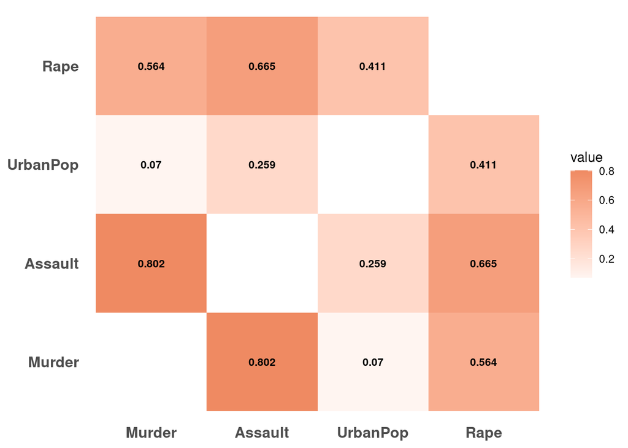

```r
df_Q10 = melt(round(cor(df_arrest, use = "pairwise.complete.obs"), 3)) # Create correlation matrix, round to 3 decimal places
df_Q10 = subset(df_Q10, value < 1) # Subset data frame by multiple column values with boolean operators
ggplot(df_Q10, aes(Var1, Var2)) + geom_tile(aes(fill = value)) + geom_text(aes(label = value), size = 3, fontface = "bold") + scale_fill_gradient2(low = "#67a9cf", high = "#ef8a62") +theme_minimal() +theme(panel.grid.major = element_blank(), panel.grid.minor = element_blank(),  panel.border = element_blank(),panel.background = element_blank(), axis.title = element_blank(), axis.text = element_text(size = 12, face = "bold")) # Create correplation heatmap with formatting/style options
```

This file can be viewed at: https://github.com/andrewcistola/PHC6194_student/_code/A01_code.html  
© Andrew S Cistola MPH